# Grammar of Graphics practice

Author

Andrew Irwin

Published

January 27, 2026

```r
library(tidyverse)
library(socviz) # data
library(datasets) # data
library(palmerpenguins) # data
library(gapminder) # data
```

Practice making plots of these data: `gss_sm`, `gss_lon`, `penguins`, `penguins_raw`, `gapminder`, and many others in the `datasets` package.

Examine the data using `View`, `glimpse`. Read the help pages about each dataset.

```r
glimpse(ToothGrowth)
```

```
Rows: 60
Columns: 3
$ len  <dbl> 4.2, 11.5, 7.3, 5.8, 6.4, 10.0, 11.2, 11.2, 5.2, 7.0, 16.5, 16.5,…
$ supp <fct> VC, VC, VC, VC, VC, VC, VC, VC, VC, VC, VC, VC, VC, VC, VC, VC, V…
$ dose <dbl> 0.5, 0.5, 0.5, 0.5, 0.5, 0.5, 0.5, 0.5, 0.5, 0.5, 1.0, 1.0, 1.0, …
```

```r
glimpse(gss_sm)
```

```
Rows: 2,867
Columns: 32
$ year        <dbl> 2016, 2016, 2016, 2016, 2016, 2016, 2016, 2016, 2016, 2016…
$ id          <dbl> 1, 2, 3, 4, 5, 6, 7, 8, 9, 10, 11, 12, 13, 14, 15, 16, 17,…
$ ballot      <labelled> 1, 2, 3, 1, 3, 2, 1, 3, 1, 3, 2, 1, 2, 3, 2, 3, 3, 2,…
$ age         <dbl> 47, 61, 72, 43, 55, 53, 50, 23, 45, 71, 33, 86, 32, 60, 76…
$ childs      <dbl> 3, 0, 2, 4, 2, 2, 2, 3, 3, 4, 5, 4, 3, 5, 7, 2, 6, 5, 0, 2…
$ sibs        <labelled> 2, 3, 3, 3, 2, 2, 2, 6, 5, 1, 4, 4, 3, 6, 0, 1, 3, 8,…
$ degree      <fct> Bachelor, High School, Bachelor, High School, Graduate, Ju…
$ race        <fct> White, White, White, White, White, White, White, Other, Bl…
$ sex         <fct> Male, Male, Male, Female, Female, Female, Male, Female, Ma…
$ region      <fct> New England, New England, New England, New England, New En…
$ income16    <fct> $170000 or over, $50000 to 59999, $75000 to $89999, $17000…
$ relig       <fct> None, None, Catholic, Catholic, None, None, None, Catholic…
$ marital     <fct> Married, Never Married, Married, Married, Married, Married…
```

[output cut: 19 more lines]

```r
glimpse(penguins)
```

```
Rows: 344
Columns: 8
$ species           <fct> Adelie, Adelie, Adelie, Adelie, Adelie, Adelie, Adel…
$ island            <fct> Torgersen, Torgersen, Torgersen, Torgersen, Torgerse…
$ bill_length_mm    <dbl> 39.1, 39.5, 40.3, NA, 36.7, 39.3, 38.9, 39.2, 34.1, …
$ bill_depth_mm     <dbl> 18.7, 17.4, 18.0, NA, 19.3, 20.6, 17.8, 19.6, 18.1, …
$ flipper_length_mm <int> 181, 186, 195, NA, 193, 190, 181, 195, 193, 190, 186…
$ body_mass_g       <int> 3750, 3800, 3250, NA, 3450, 3650, 3625, 4675, 3475, …
$ sex               <fct> male, female, female, NA, female, male, female, male…
$ year              <int> 2007, 2007, 2007, 2007, 2007, 2007, 2007, 2007, 2007…
```

## Aesthetic mappings to use

x, y, color, fill, shape, size, group

## Geometries to try

- geom_bar, geom_count,
- geom_point, geom_line, geom_boxplot, geom_jitter,
- geom_histogram, geom_density,
- geom_hline, geom_vline, geom_rug,
- stat_summary,
- geom_function

Which should you use with categorical data? quantitative data? A mixture?

What happens if you use the wrong kind of data?

Take a look at the help for each geom using the Help panel in Rstudio or on the ggplot [website](https://ggplot2.tidyverse.org/index.html).

Try a few simple themes:

- theme_bw(base_size = 14)
- theme_minimal(base_family = “serif”) # sans, mono, font name
- theme_classic()

As we practice, we will describe each geom here and provide some examples.

## Examples

Created in class using the suggestions above.

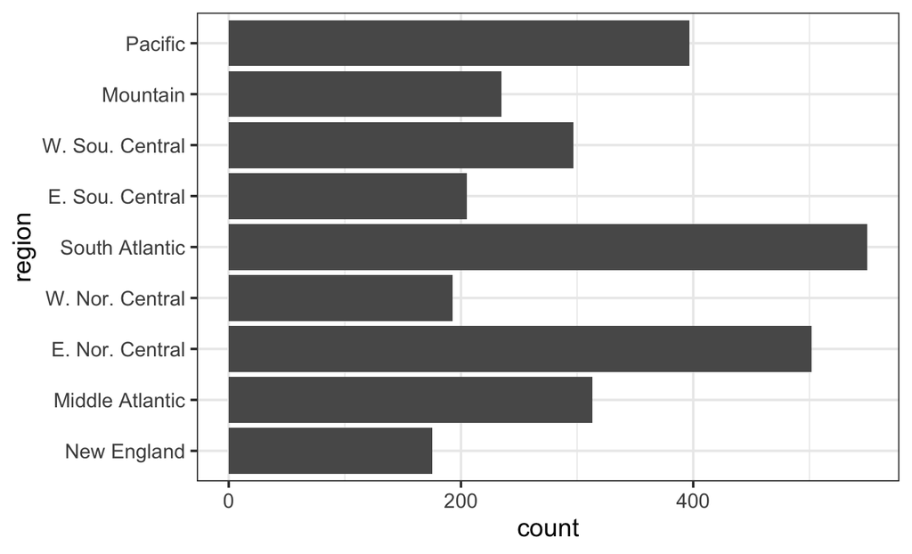

```r
gss_sm |> ggplot(aes(y = region)) + geom_bar() +
  theme_bw(base_size=14)
```

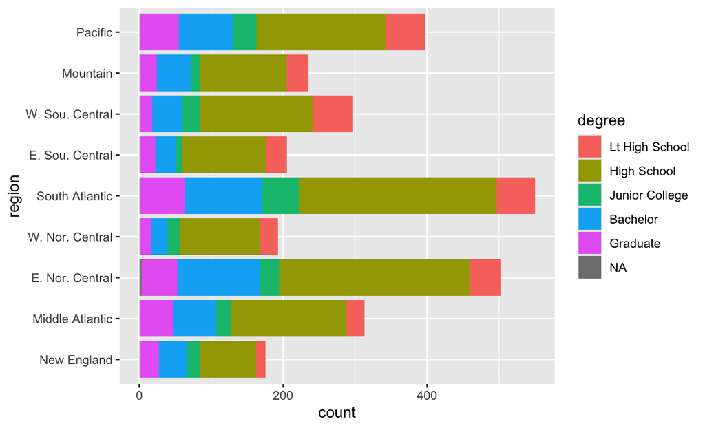

```r
gss_sm |> ggplot() +
  geom_bar(aes(y = region, fill = degree ))
```

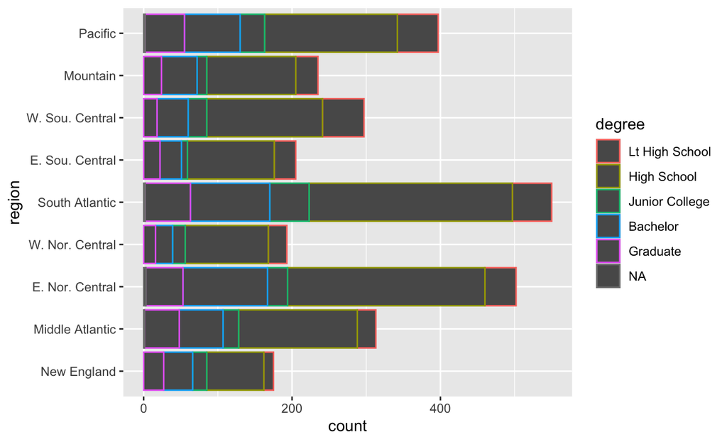

```r
gss_sm |> ggplot() +
  geom_bar(aes(y = region, colour = degree ))
```

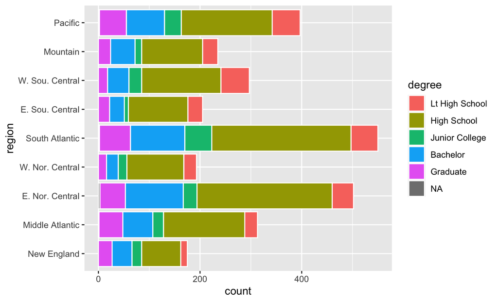

```r
gss_sm |> ggplot() +
  geom_bar(aes(y = region, fill = degree ), color = "white")
```

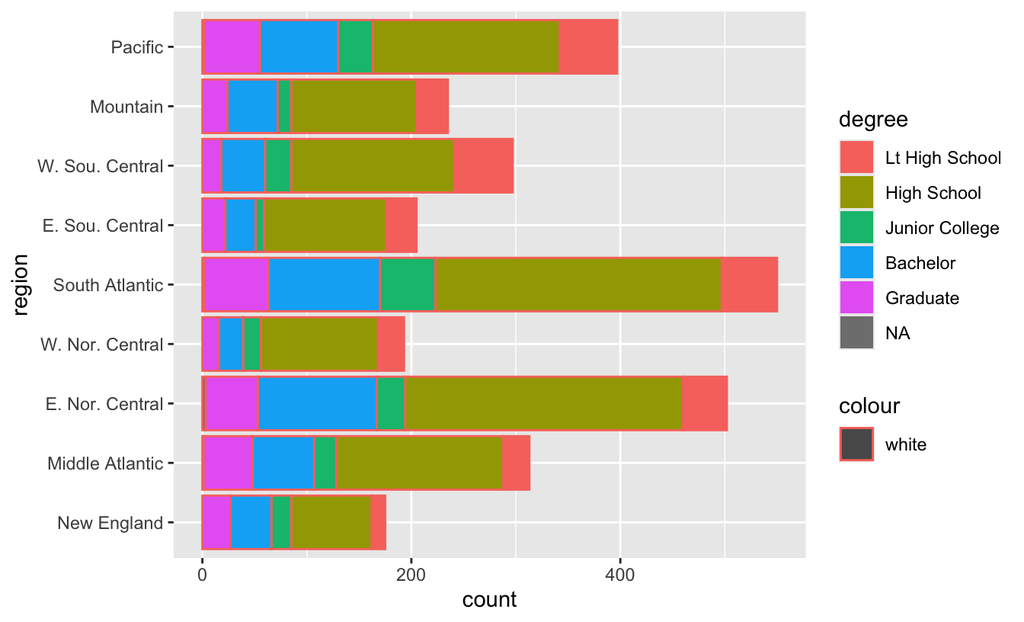

```r
gss_sm |> ggplot() +
  geom_bar(aes(y = region, fill = degree, color = "white"))
```

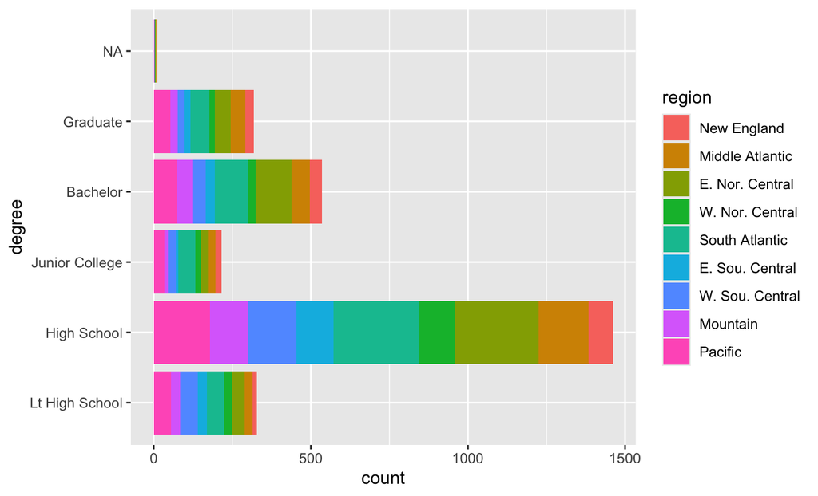

```r
gss_sm |> ggplot() +
  geom_bar(aes(y = degree, fill = region ))
```

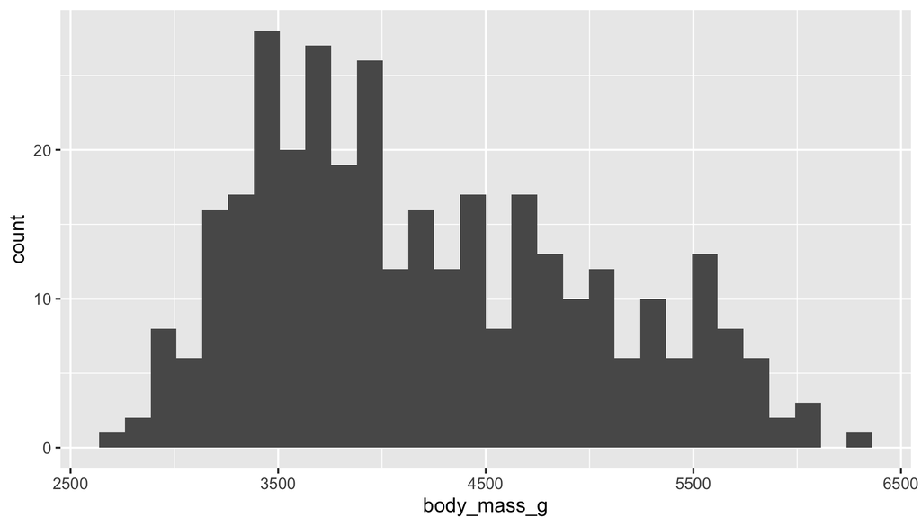

```r
penguins |> ggplot() +
  geom_histogram(aes(body_mass_g))
```

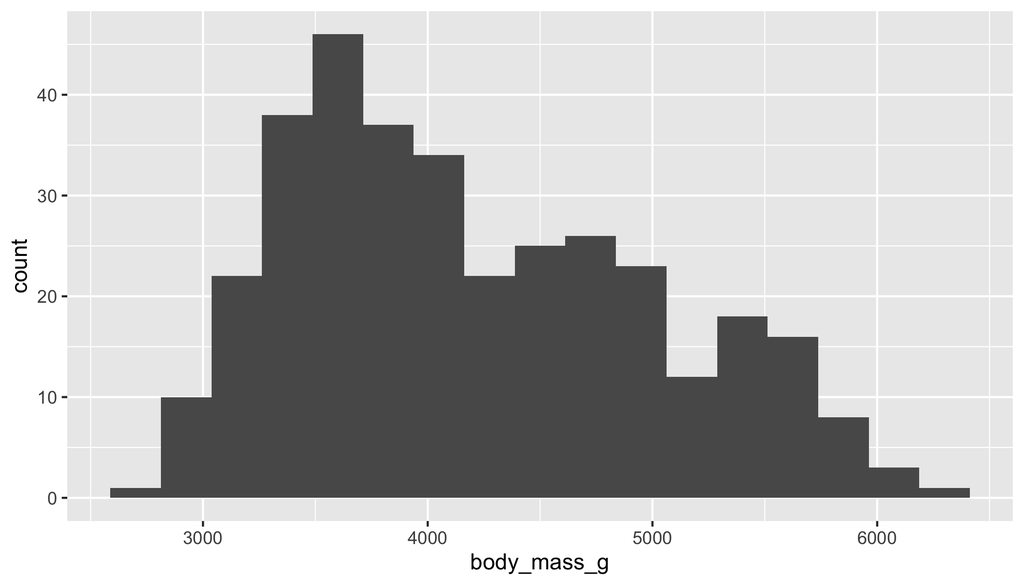

```r
penguins |> ggplot() +
  geom_histogram(aes(body_mass_g), binwidth = 225)
```

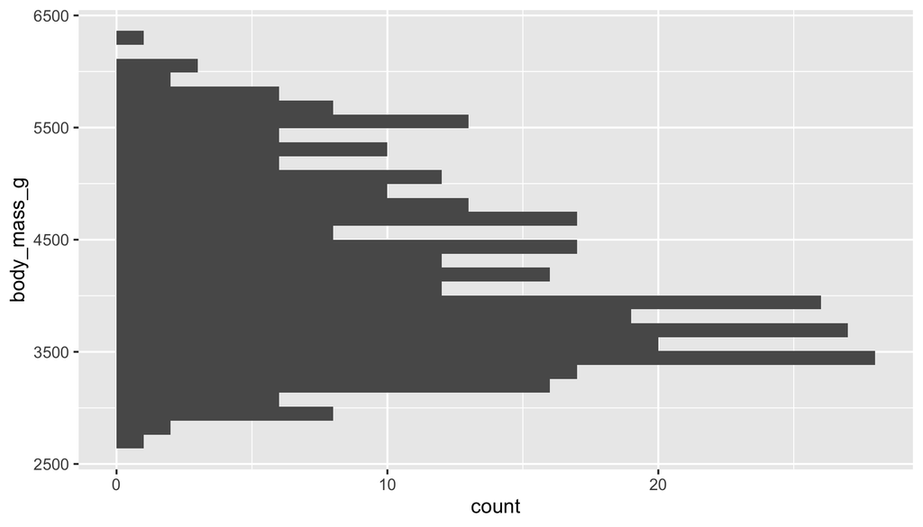

```r
penguins |> ggplot() +
  geom_histogram(aes(y = body_mass_g))
```

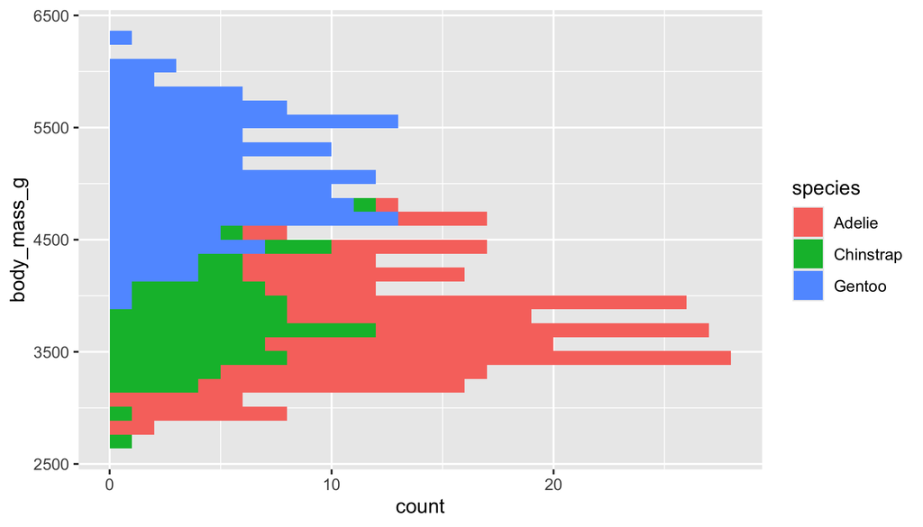

```r
penguins |> ggplot() +
  geom_histogram(aes(y = body_mass_g, fill = species))
```

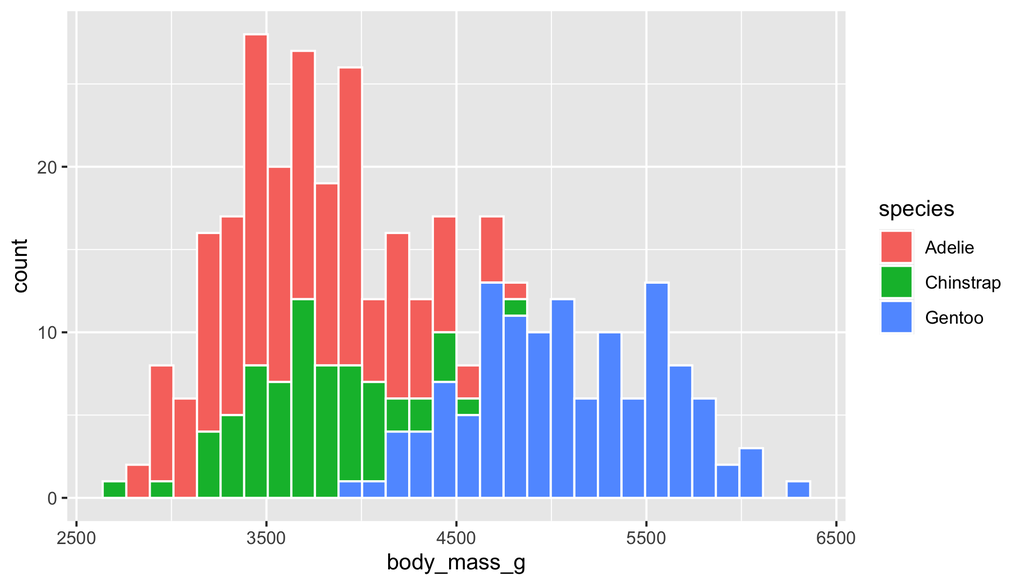

```r
penguins |> ggplot() +
  geom_histogram(aes(x = body_mass_g, fill = species), color = "white")
```

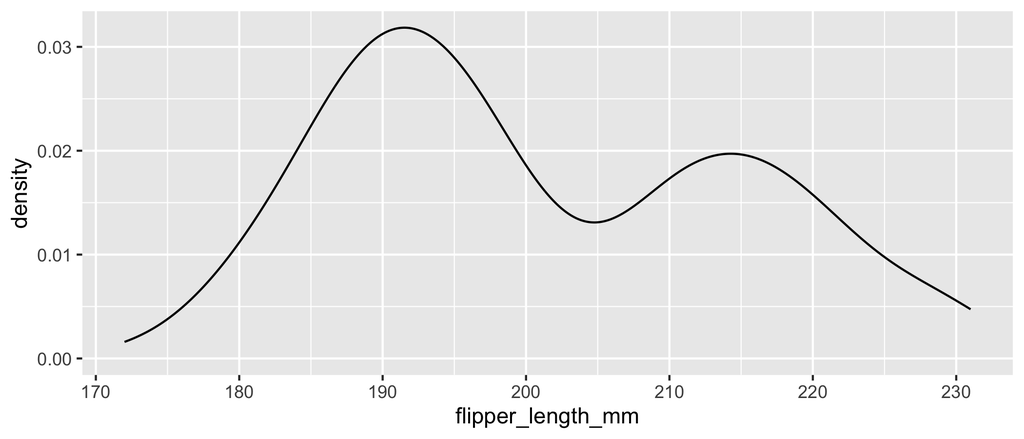

```r
penguins |> ggplot() +
  geom_density(aes(flipper_length_mm))
```

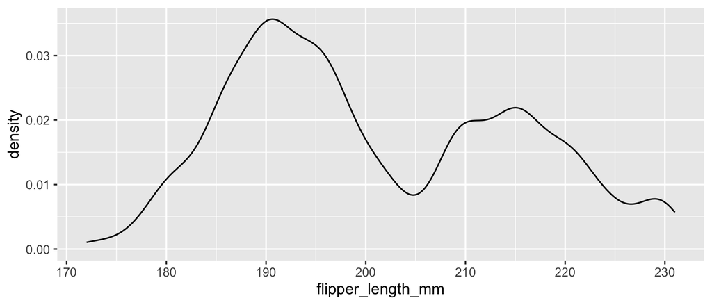

```r
penguins |> ggplot() +
  geom_density(aes(flipper_length_mm), bw = 2)
```

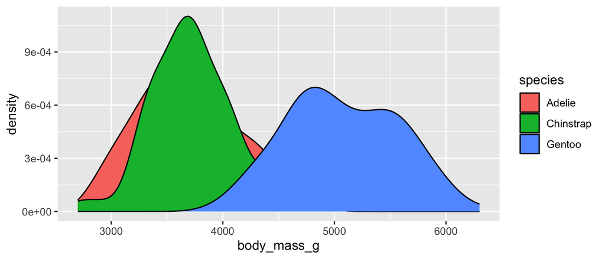

```r
penguins |> ggplot() +
  geom_density(aes(x = body_mass_g, fill = species))
```

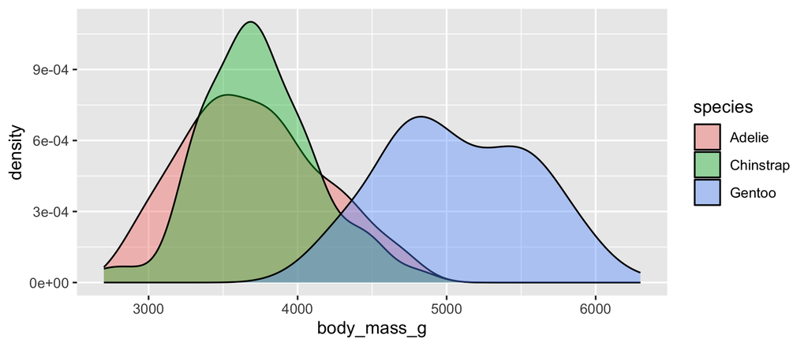

```r
penguins |> ggplot() +
  geom_density(aes(x = body_mass_g, fill = species), alpha = 0.4)
```

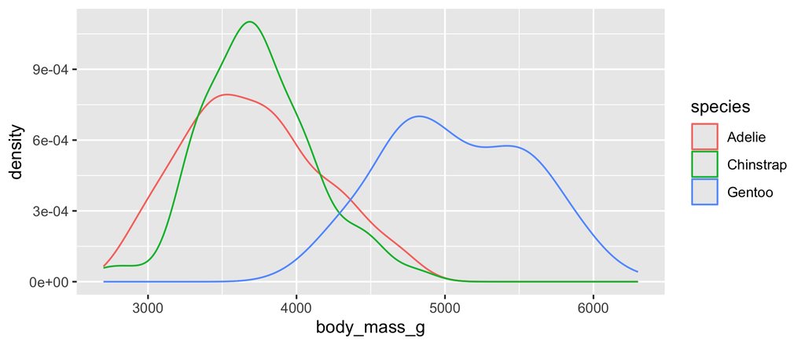

```r
penguins |> ggplot() +
  geom_density(aes(x = body_mass_g, colour = species))
```

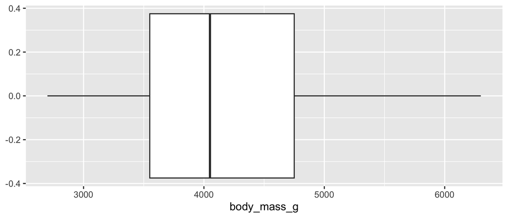

```r
penguins |> ggplot() +
  geom_boxplot(aes(body_mass_g))
```

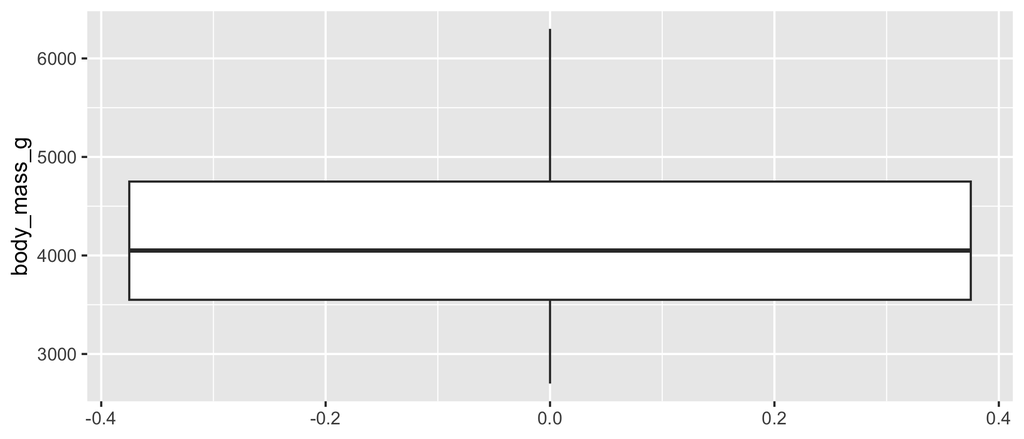

```r
penguins |> ggplot() +
  geom_boxplot(aes(y = body_mass_g))
```

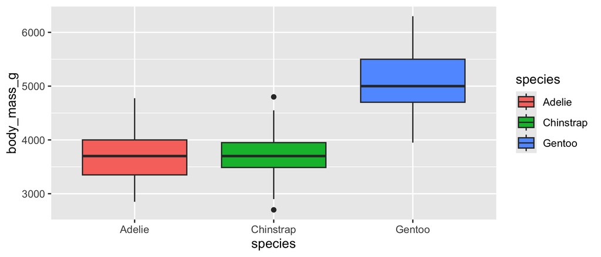

```r
penguins |> ggplot() +
  geom_boxplot(aes(y = body_mass_g, x = species, fill = species))
```

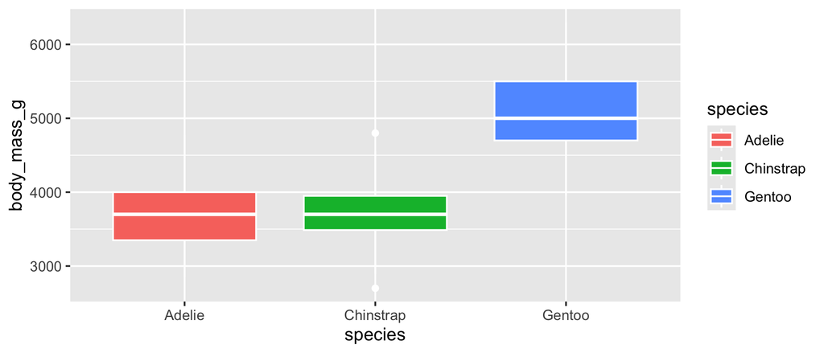

```r
penguins |> ggplot() +
  geom_boxplot(aes(y = body_mass_g, x = species, fill = species), color = "white")
```

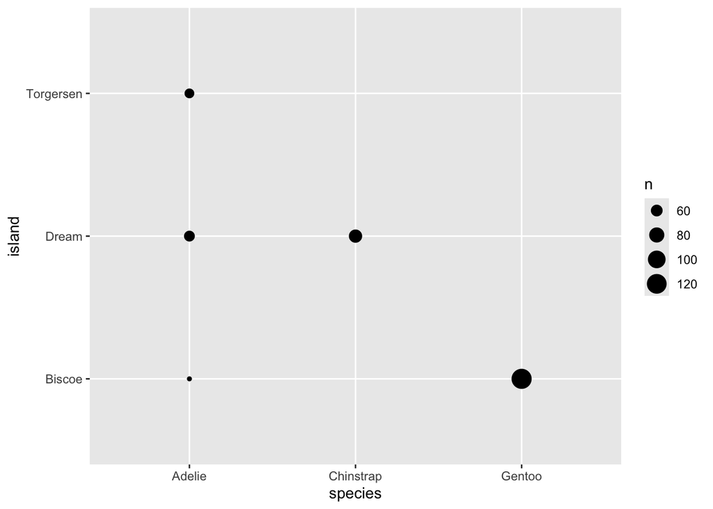

```r
penguins |> ggplot() +
  geom_count(aes(species, island))
```

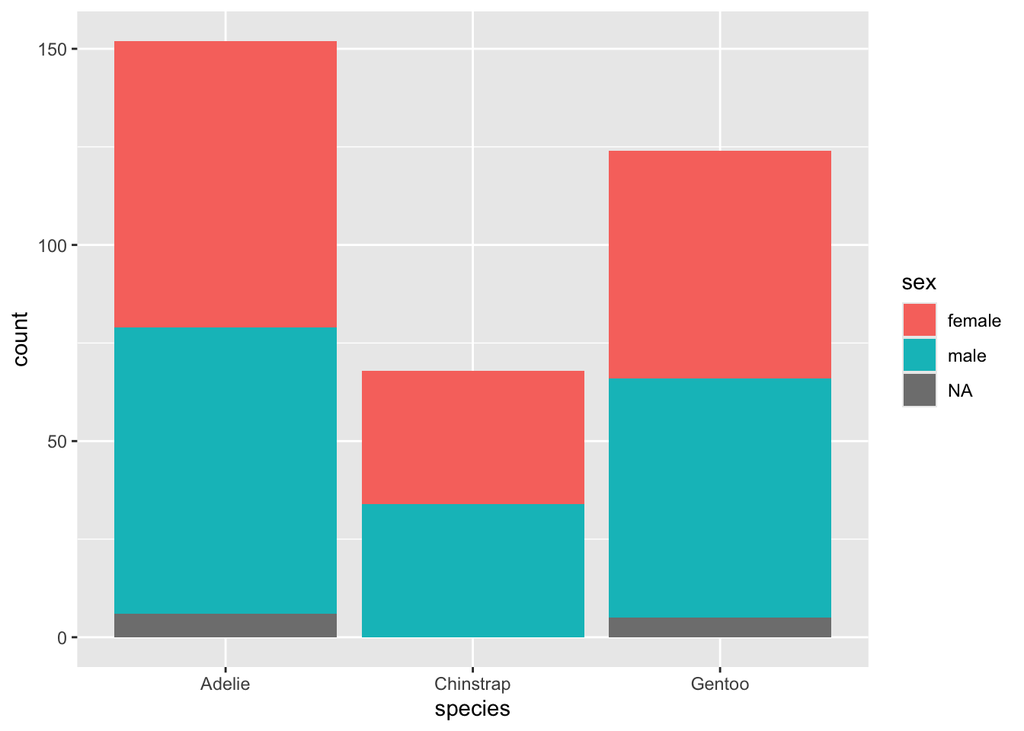

```r
penguins |> ggplot() +
  geom_bar(aes(species, fill = sex))
```

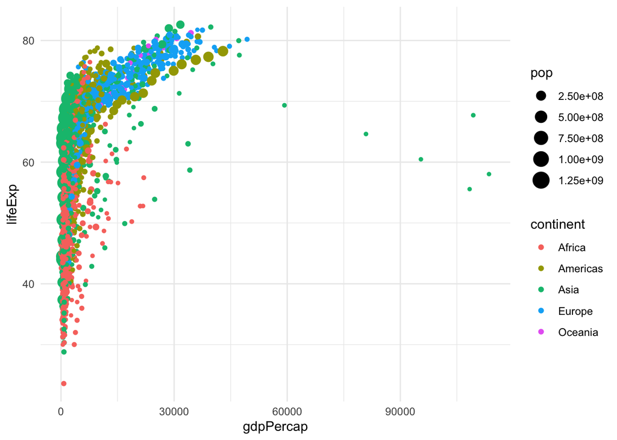

```r
gapminder |> ggplot() +
  geom_point(aes(x = gdpPercap, y = lifeExp, size = pop, color = continent)) +
  theme_minimal()
```

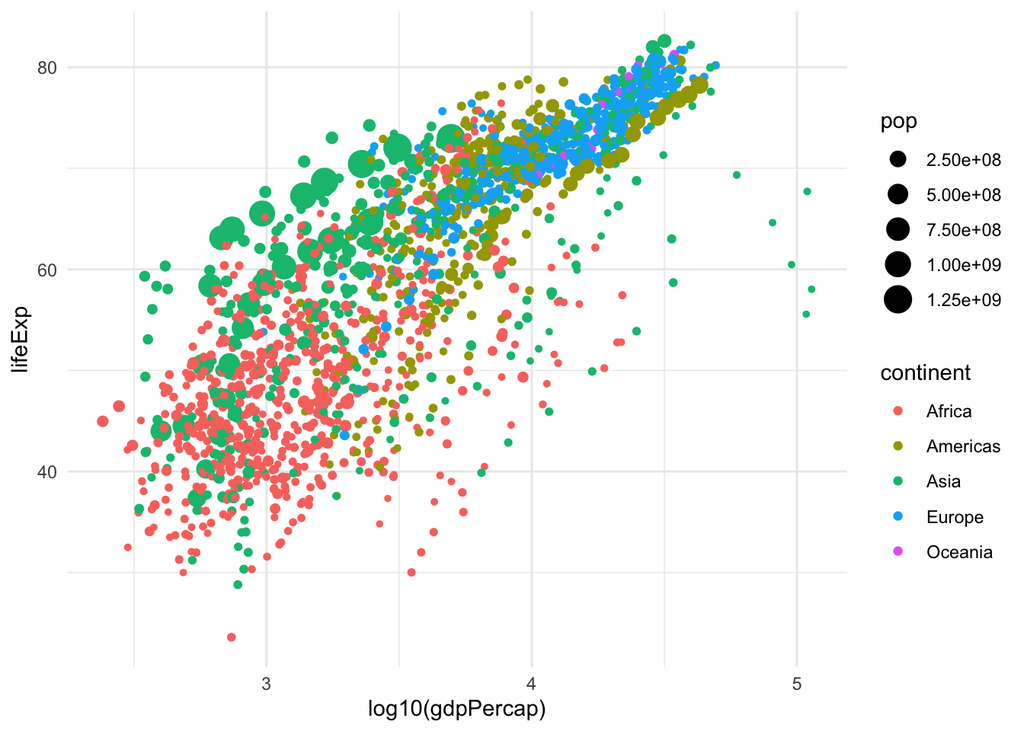

```r
gapminder |> ggplot() +
  geom_point(aes(x = log10(gdpPercap), y = lifeExp, size = pop, color = continent)) +
  theme_minimal()
```

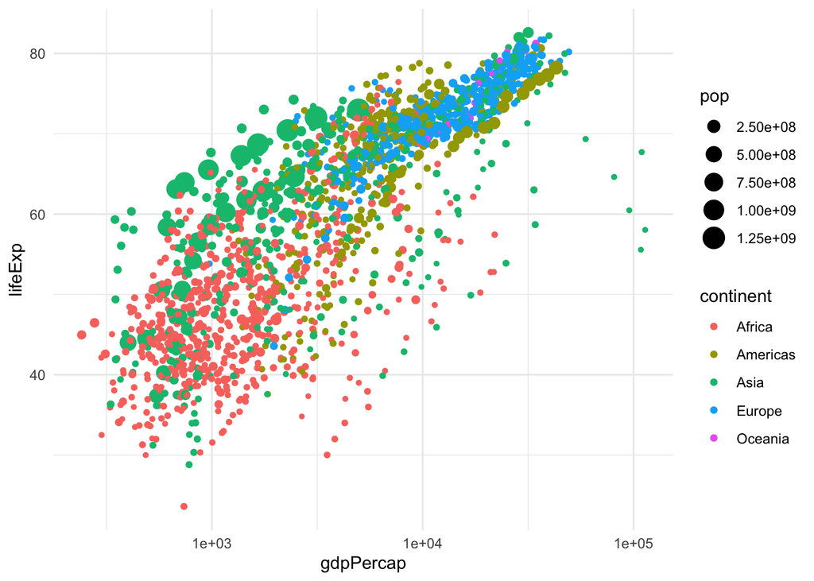

```r
gapminder |> ggplot() +
  geom_point(aes(x = gdpPercap, y = lifeExp, size = pop, color = continent)) +
  scale_x_log10() +
  theme_minimal()
```

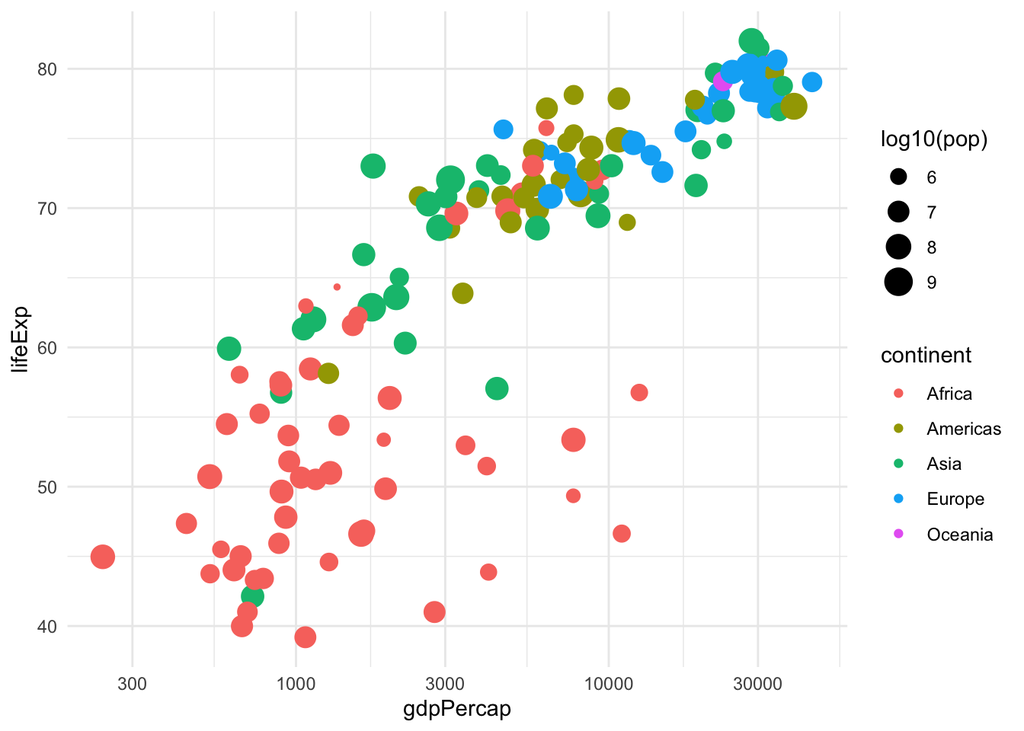

```r
gapminder |> filter(year == 2002) |>
  ggplot() +
  geom_point(aes(x = gdpPercap, y = lifeExp, size = log10(pop), color = continent)) +
  scale_x_log10() +
  theme_minimal()
```

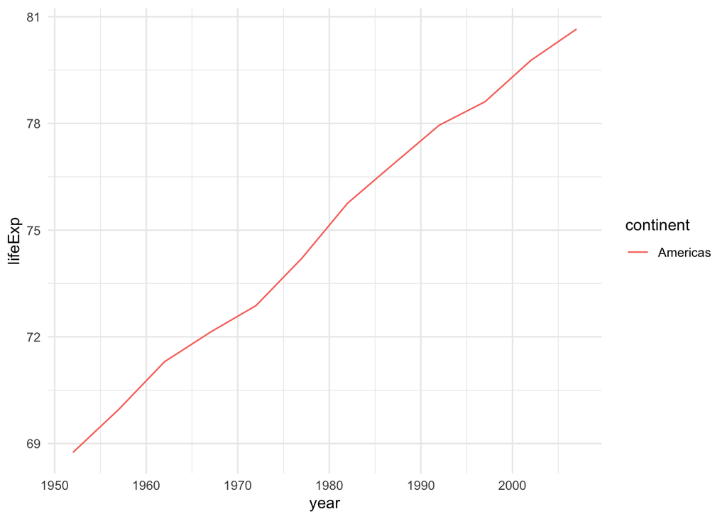

```r
gapminder |> filter(country == "Canada") |>
  ggplot() +
  geom_line(aes(x = year, y = lifeExp, color = continent)) +
  theme_minimal()
```

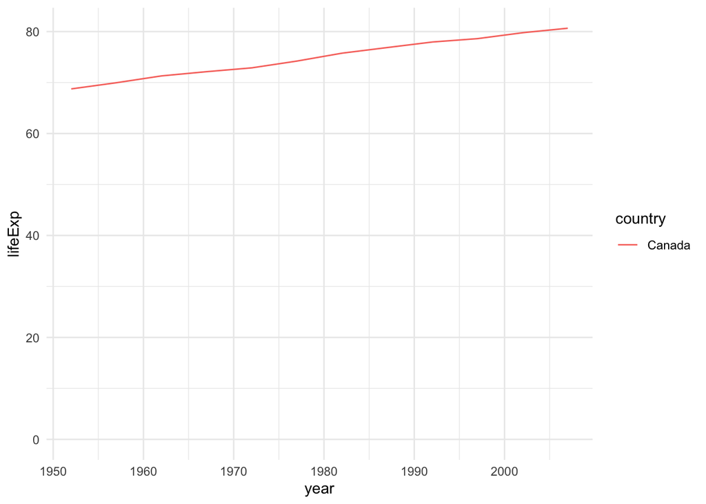

```r
gapminder |> filter(country == "Canada") |>
  ggplot() +
  geom_line(aes(x = year, y = lifeExp, color = country)) +
  ylim(0, NA) +
  theme_minimal()
```

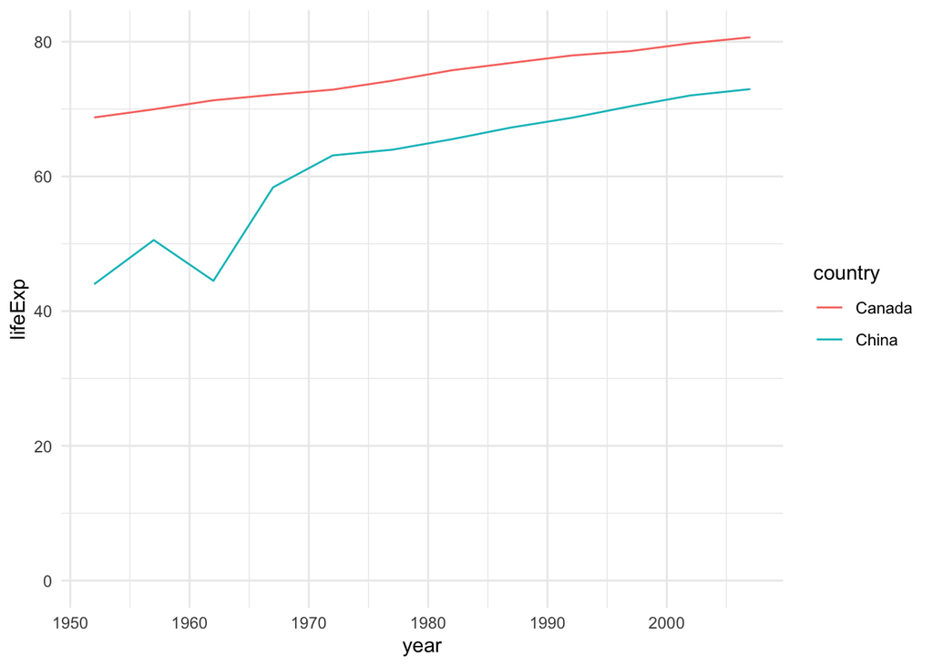

```r
gapminder |> filter(country == "Canada"  | country == "China") |>
  ggplot() +
  geom_line(aes(x = year, y = lifeExp, color = country)) +
  ylim(0, NA) +
  theme_minimal()
```

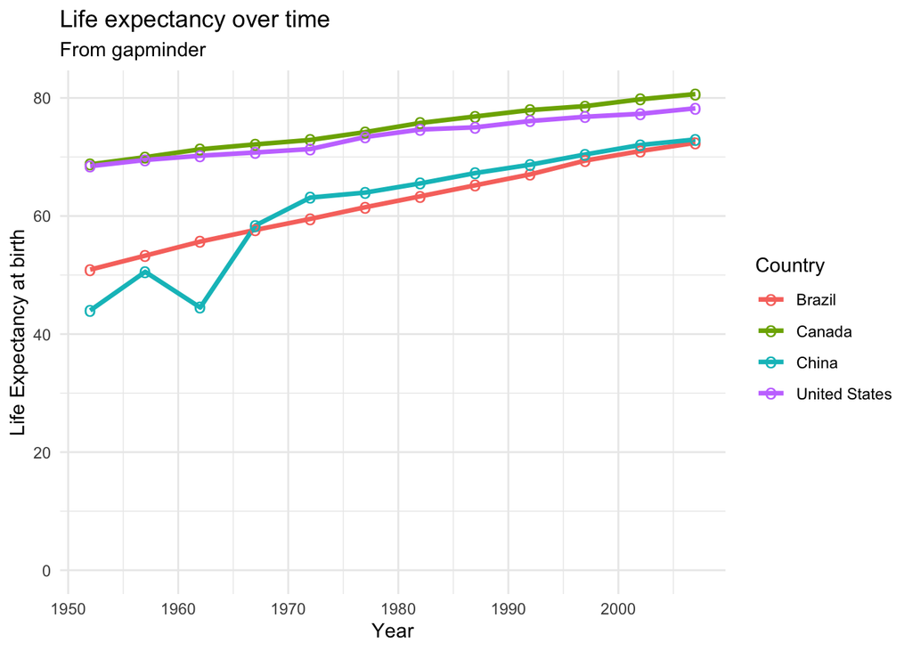

```r
gapminder |> filter(country %in% c("Canada", "China", "Brazil", "United States")) |>
  ggplot() +
  geom_line(aes(x = year, y = lifeExp, color = country), linewidth = 1.2) +
  geom_point(aes(x = year, y = lifeExp, color = country), size = 4, shape = "o") +
  ylim(0, NA) +
  theme_minimal() +
  labs(x = "Year", y = "Life Expectancy at birth",
       colour = "Country",
       title = "Life expectancy over time",
       subtitle = "From gapminder")
```